# Raghu_606_Project_Final

Raghu Ramnath

3/11/2017

## Part I - Introduction

In this Project, I will analyze the shooting incidents in all the 50 States in US based on the data from year 2013 to 2015. The objective is to find the States having highest shooting rate and people killed and wounded and see if there is any trend by comparison of the count of incidents. Has the incidents raised or lowered in the three years. Is there any particular month having high incident rate in any state. This would help to understand if any measure has been taken already or need to take to lower the incidents. This would also warn in terms of understanding high crime prone State.

### Environment Prep

```r
if (!require('dplyr')) install.packages('dplyr')
if (!require('stringr')) install.packages('stringr')
if (!require('ggplot2')) install.packages('ggplot2')
if (!require('lubridate')) install.packages('lubridate')
if (!require('tidyr')) install.packages('tidyr')
if (!require('doBy')) install.packages('doBy')
if (!require('knitr')) install.packages('knitr')
if (!require('reshape')) install.packages('reshape')
if (!require('lattice')) install.packages('lattice')
```

## Part 2 - Data

```r
yr_2013 <- read.csv(file = ("https://raw.githubusercontent.com/raghu74us/606/master/2013_shooter.csv"),sep =",")

yr_2014 <- read.csv(file = ("https://raw.githubusercontent.com/BuzzFeedNews/2015-12-mass-shooting-intervals/master/data/2014MASTER.csv"),sep =",")

yr_2015 <- read.csv(file = ("https://raw.githubusercontent.com/BuzzFeedNews/2015-12-mass-shooting-intervals/master/data/2015CURRENT.csv"),sep =",")
```

### Cases

There are only 3 years of data available which totals to 1050 observations and 9 variables. This data set has the year, month, City, state and incident date and total killed and wounded.

### Describe the method of data collection.

Data is available in Buzfeed News. There are data files for each year from 2013 to 2015.

### Type of study

This study is observational.

### Data Source

Data is available under the below link. https://github.com/BuzzFeedNews/2015-12-mass-shooting-intervals/tree/master/data

### Response

Response variable is the number of incidents in a month in a city, State. It is numerical.

### Explanatory

Number of incidents each month. Has the incidents happened each month what is the count of it. This need to be done for atleast 3 years to decide which city has highest incident and the reoccurrence chances each month.

## Part 3 - Exploratory data analysis

```r
#not including the columns that are not needed for analysis.
yr_2013 <- yr_2013[ , c('date', 'killed', 'wounded', 'location')]
colnames(yr_2013) <- c('Date', 'Dead', 'Injured', 'Location')
yr_2013$Year <- "2013"
yr_2014 <- yr_2014[ , c('Date', 'Dead', 'Injured', 'Location')]
yr_2014$Year <- "2014"
yr_2015 <- yr_2015[ , c('Date', 'Dead', 'Injured', 'Location')]
yr_2015$Year <- "2015"

sh <-rbind(yr_2013, yr_2014, yr_2015)

     #split state and city based on location
     str(sh)
```

```
## 'data.frame':    1050 obs. of  5 variables:
##  $ Date    : Factor w/ 613 levels "1/1/13","1/10/13",..: 1 1 1 1 10 11 11 11 2 3 ...
##  $ Dead    : int  4 1 0 1 4 5 2 3 3 1 ...
##  $ Injured : int  0 3 4 4 0 0 2 1 2 4 ...
##  $ Location: Factor w/ 557 levels "Aguas Buenas, PR",..: 199 87 135 122 9 228 76 50 154 229 ...
##  $ Year    : chr  "2013" "2013" "2013" "2013" ...
```

```r
     head(sh,5)
```

```
##     Date Dead Injured       Location Year
## 1 1/1/13    4       0 Sacramento, CA 2013
## 2 1/1/13    1       3  Hawthorne, CA 2013
## 3 1/1/13    0       4 McKeesport, PA 2013
## 4 1/1/13    1       4     Lorain, OH 2013
## 5 1/5/13    4       0     Aurora, CO 2013
```

```r
     cit_st<-str_split_fixed(sh$Location, ",", 2)
     sh   <- cbind(sh, cit_st)
     sh$Year<- as.factor(sh$Year)
     colnames(sh) <- c('date', 'killed', 'wounded', 'location', "Year","City", "State")
     sh$State<- as.factor(sh$State)
     #Add month and year based on date.
     sh$date <- mdy(sh$date)

     str(sh)
```

```
## 'data.frame':    1050 obs. of  7 variables:
##  $ date    : Date, format: "2013-01-01" "2013-01-01" ...
##  $ killed  : int  4 1 0 1 4 5 2 3 3 1 ...
##  $ wounded : int  0 3 4 4 0 0 2 1 2 4 ...
##  $ location: Factor w/ 557 levels "Aguas Buenas, PR",..: 199 87 135 122 9 228 76 50 154 229 ...
##  $ Year    : Factor w/ 3 levels "2013","2014",..: 1 1 1 1 1 1 1 1 1 1 ...
##  $ City    : Factor w/ 522 levels " Fort Bend County",..: 401 194 272 251 25 474 178 123 306 475 ...
##  $ State   : Factor w/ 69 levels ""," AK"," AL",..: 8 8 53 48 9 51 42 64 29 3 ...
```

```r
     #y1<-year(sh$date)
     m1<-as.character(sh$date, format="%b")
     d1<-as.character(sh$date, format="%d")

     df1  <- cbind(d1,m1)
     colnames(df1)  <- c('day','month')

     sh <- cbind(sh , df1)

     sh$State <- trimws(toupper(sh$State))
     sh$State <- replace(sh$State, sh$State=="ILLINOIS", "IL")
     sh$State <- replace(sh$State, sh$State=="TENNESSEE", "TN")
     sh$State <- replace(sh$State, sh$State=="KANSAS", "KS")
     sh$State <- replace(sh$State, sh$State=="LOUISIANA", "MO")
     sh$State <- replace(sh$State, sh$State=="OHIO", "OH")
     sh$State <- replace(sh$State, sh$State=="D.C.", "DC")
     sh$State <- replace(sh$State, sh$State=="PUERTO RICO", "NA")
     sh$State <- replace(sh$State, sh$State=="", "NA")


     sh_us_sum <- sh %>%
         select(Year,State,killed,wounded) %>%
          group_by(Year,State )  %>%
            summarise( total_incidents= n() ) %>%
               top_n(5)
```

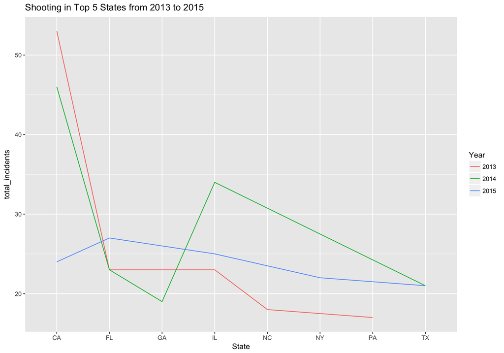

```r
     ggplot(sh_us_sum, aes(State,total_incidents)) +
    geom_line(aes(color=Year, group=Year)) +
     ggtitle("Shooting in Top 5 States from 2013 to 2015")
```

```r
     sh1 <- sh[ !((trimws(sh$State)) != "CA"), ]

    #summarize by total killed and wounded in California
     sh_kw_ca <- sh1  %>%
        select(Year,State,month,killed,wounded) %>%
          group_by(Year,State,month )  %>%
           summarise_each(funs(sum) ) %>%
             arrange(Year,State,month)

     sh_kw_ca$Tot_kw<- sh_kw_ca$killed + sh_kw_ca$wounded

    #summarize by total incidents in California
      sh_inc_ca <- sh1  %>%
        select(Year,State,month,killed+wounded) %>%
          group_by(Year,State,month )  %>%
           summarise( total_incidents= n() )


knitr::opts_chunk$set(echo = TRUE)
```

### Plots

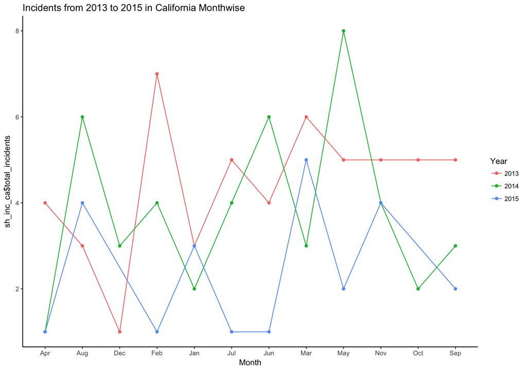

```r
#Incidents from 2013 to 2015 in California Monthwise.
ggplot( sh_inc_ca , aes(sh_inc_ca$month,
                sh_inc_ca$total_incidents, group=Year, colour=Year)) +
  geom_line() +
  geom_point() +
  labs(x="Month", colour="Year") +
  theme_classic() +
     ggtitle("Incidents from 2013 to 2015 in California Monthwise")
```

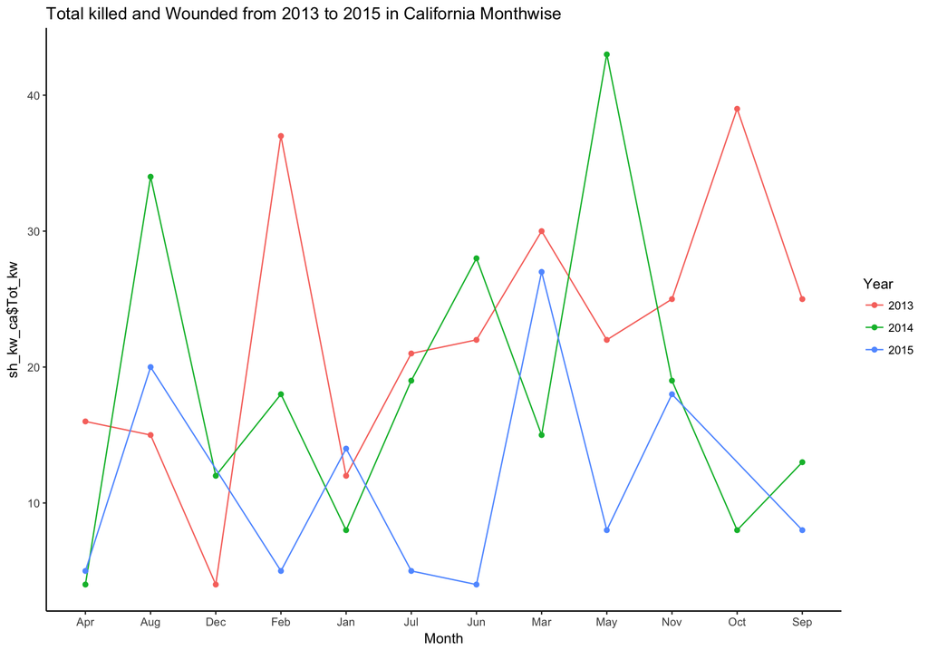

```r
#Total Killed and Wounded from 2013 to 2015 in California Monthwise.
ggplot( sh_kw_ca , aes( sh_kw_ca$month,sh_kw_ca$Tot_kw, group=Year, colour=Year))  +
  geom_line() +
  geom_point() +
  labs(x="Month", colour="Year") +
  theme_classic() +
    ggtitle("Total killed and Wounded from 2013 to 2015 in California Monthwise")
```

```r
knitr::opts_chunk$set(echo = TRUE)
```

## Part 4 - Inference

### Hypothesis

$H_A:$ The avg monthly shooting across some or all months does vary.

### Check Conditions

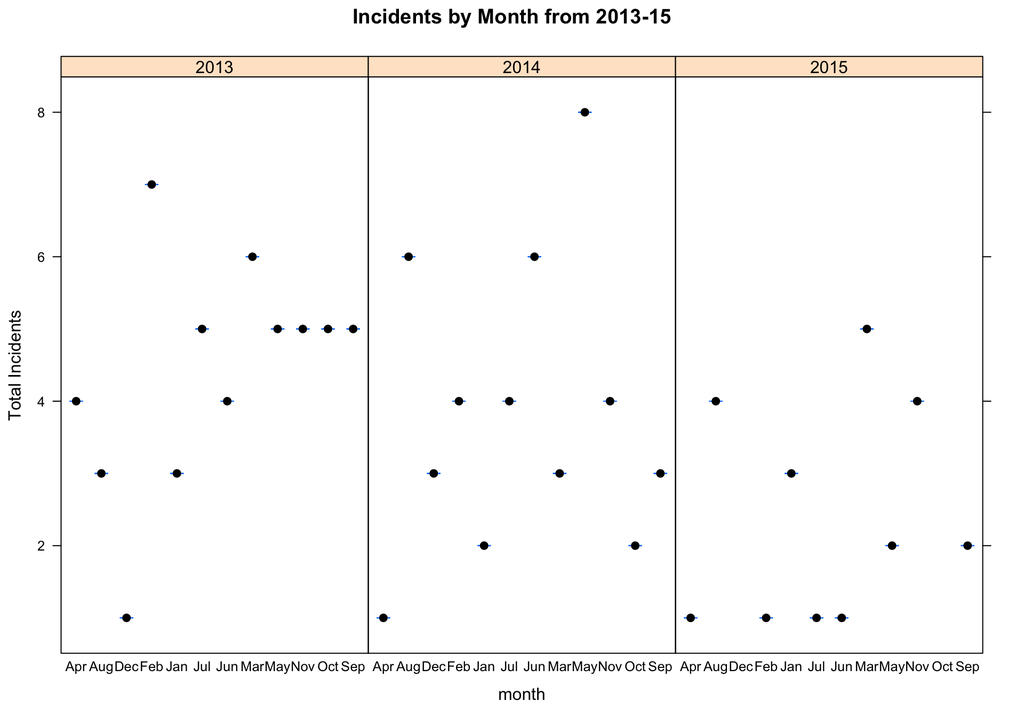

```r
#box plot from Jan to Dec in CA from 2013-15

bwplot(sh_inc_ca$total_incidents ~ sh_inc_ca$month | sh_inc_ca$Year, sh_inc_ca,main="Incidents by Month from 2013-15",xlab="month",ylab="Total Incidents")
```

```r
#wide format
      sh_inc_w <- sh_inc_ca  %>%
                   spread(month, total_incidents, fill=NA, convert = FALSE, drop=TRUE, sep=NULL)

      summary(sh_inc_w)
```

```
##    Year      State                Apr           Aug             Dec
##  2013:1   Length:3           Min.   :1.0   Min.   :3.000   Min.   :1.0
##  2014:1   Class :character   1st Qu.:1.0   1st Qu.:3.500   1st Qu.:1.5
##  2015:1   Mode  :character   Median :1.0   Median :4.000   Median :2.0
##                              Mean   :2.0   Mean   :4.333   Mean   :2.0
##                              3rd Qu.:2.5   3rd Qu.:5.000   3rd Qu.:2.5
##                              Max.   :4.0   Max.   :6.000   Max.   :3.0
##                                                            NA's   :1
##       Feb           Jan             Jul             Jun
##  Min.   :1.0   Min.   :2.000   Min.   :1.000   Min.   :1.000
##  1st Qu.:2.5   1st Qu.:2.500   1st Qu.:2.500   1st Qu.:2.500
##  Median :4.0   Median :3.000   Median :4.000   Median :4.000
##  Mean   :4.0   Mean   :2.667   Mean   :3.333   Mean   :3.667
##  3rd Qu.:5.5   3rd Qu.:3.000   3rd Qu.:4.500   3rd Qu.:5.000
##  Max.   :7.0   Max.   :3.000   Max.   :5.000   Max.   :6.000
##
##       Mar             May           Nov             Oct
##  Min.   :3.000   Min.   :2.0   Min.   :4.000   Min.   :2.00
##  1st Qu.:4.000   1st Qu.:3.5   1st Qu.:4.000   1st Qu.:2.75
##  Median :5.000   Median :5.0   Median :4.000   Median :3.50
##  Mean   :4.667   Mean   :5.0   Mean   :4.333   Mean   :3.50
##  3rd Qu.:5.500   3rd Qu.:6.5   3rd Qu.:4.500   3rd Qu.:4.25
##  Max.   :6.000   Max.   :8.0   Max.   :5.000   Max.   :5.00
##                                                NA's   :1
##       Sep
##  Min.   :2.000
##  1st Qu.:2.500
##  Median :3.000
##  Mean   :3.333
##  3rd Qu.:4.000
##  Max.   :5.000
##
```

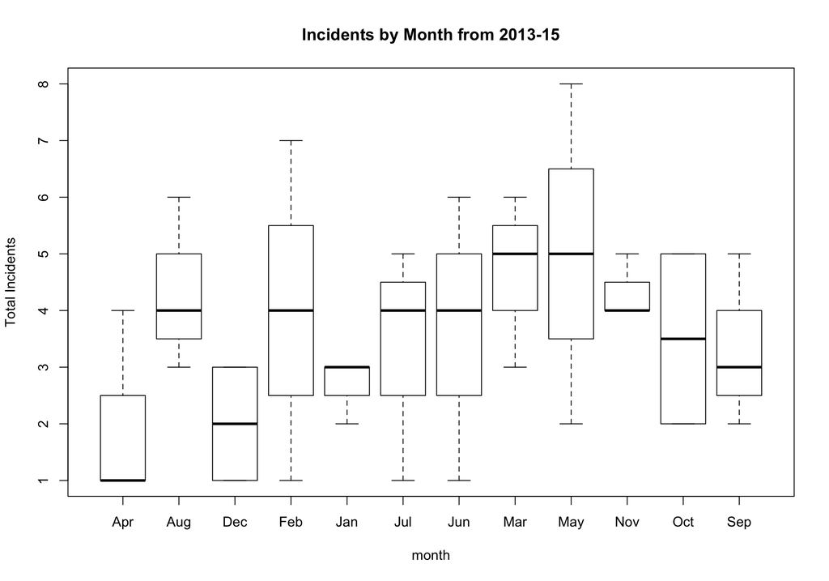

```r
      boxplot(sh_inc_w[3:14], main="Incidents by Month from 2013-15",xlab="month",ylab="Total Incidents")
```

```r
# Average mean and SD of Jan to Dec.

sh_inc_ca_msc <- data.frame(State=sh_inc_ca$State,Month= sh_inc_ca$month,Incidents= sh_inc_ca$total_incidents)

sh_inc_ca_TAS <- aggregate(Incidents ~ Month, data = sh_inc_ca_msc, function(x) c(Total = sum(x), Average = mean(x), SD = sd(x) ))

sh_inc_ca_TAS<- cbind(sh_inc_ca_TAS[-ncol(sh_inc_ca_TAS)], sh_inc_ca_TAS[[ncol(sh_inc_ca_TAS)]])

sh_inc_ca_TAS
```

```
##    Month Total  Average        SD
## 1    Apr     6 2.000000 1.7320508
## 2    Aug    13 4.333333 1.5275252
## 3    Dec     4 2.000000 1.4142136
## 4    Feb    12 4.000000 3.0000000
## 5    Jan     8 2.666667 0.5773503
## 6    Jul    10 3.333333 2.0816660
## 7    Jun    11 3.666667 2.5166115
## 8    Mar    14 4.666667 1.5275252
## 9    May    15 5.000000 3.0000000
## 10   Nov    13 4.333333 0.5773503
## 11   Oct     7 3.500000 2.1213203
## 12   Sep    10 3.333333 1.5275252
```

```
## geom_path: Each group consists of only one observation. Do you need to
## adjust the group aesthetic?
```

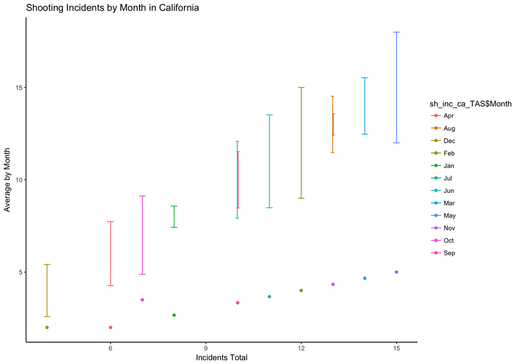

```r
p<- ggplot(sh_inc_ca_TAS, aes(x=sh_inc_ca_TAS$Total, y=sh_inc_ca_TAS$Average, group=sh_inc_ca_TAS$Month, color=sh_inc_ca_TAS$Month)) +
  geom_line() +
  geom_point()+
  geom_errorbar(aes(ymin=sh_inc_ca_TAS$Total-sh_inc_ca_TAS$SD, ymax=sh_inc_ca_TAS$Total+sh_inc_ca_TAS$SD), width=.2,
                 position=position_dodge(0.05))
#print(p)
# Finished line plot
p + labs(title="Shooting Incidents by Month in California", x="Incidents Total", y = "Average by Month")+
   theme_classic()
```

```r
knitr::opts_chunk$set(echo = TRUE)
```

We believe that the shooting data from each month is independent and varies across all months.